# item_plots_agg

Hyoshin Kim

2022 3 10

# Count plots for requests given to Note in the Pocket

## Clothing categories

In this section and the following sections, we count the number of individuals that request clothing of a given gender and size:

- An individual that requests clothing labeled as gt, gb, gu, gs, gc is considered as “female small.”
- An individual that requests clothing labeled as bt, bb, bu, bs, bc is considered as “male small.”
- An individual that requests clothing labeled as wt, wb, wu, ws, wc is considered as “female large.”
- An individual that requests clothing labeled as mt, mb, mu, ms, mc is considered as “male large.”

## Plot of Items by Date

- Based on the time plots for each clothing item (female small, male small, female large, male large), there is a recurring pattern each year. A small peak in spring, and a larger peak in fall for the number of requests, reflecting the start of the school semester.
- There seems to be a smaller number of requests during the 2020 spring semester after COVID starts.

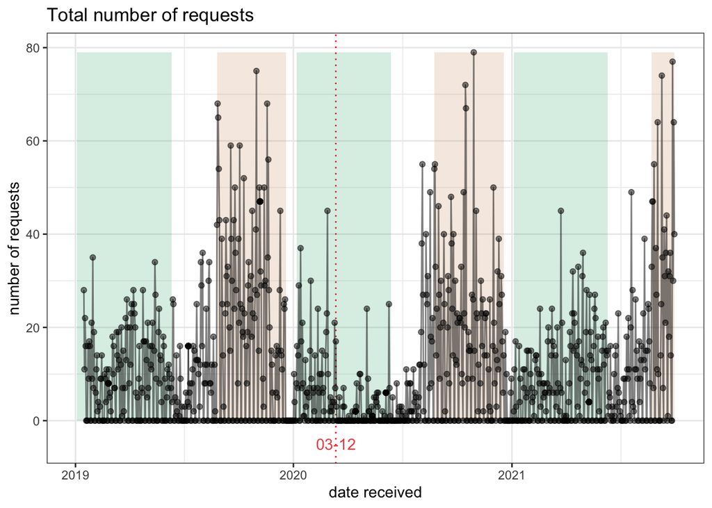

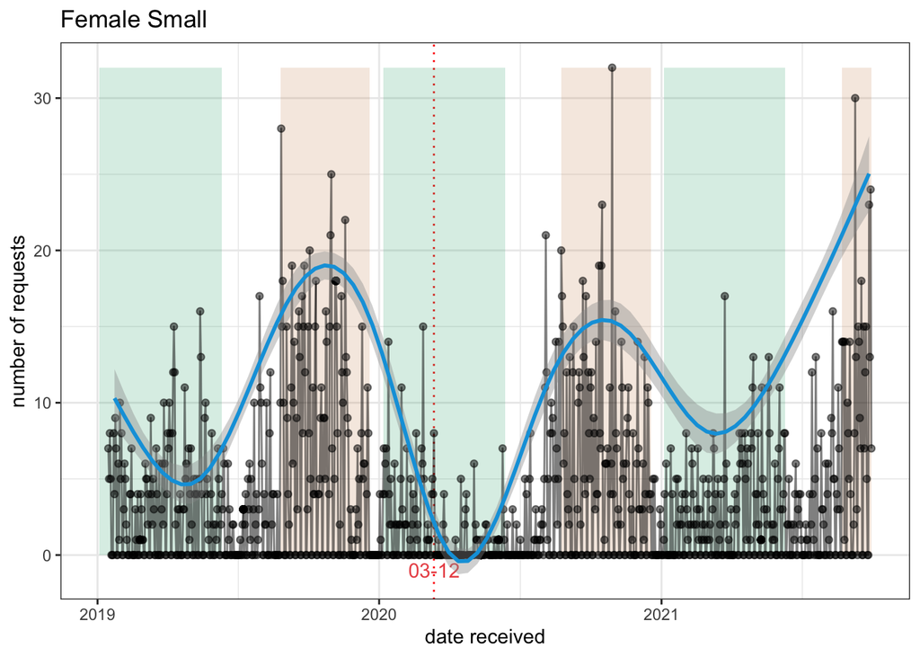

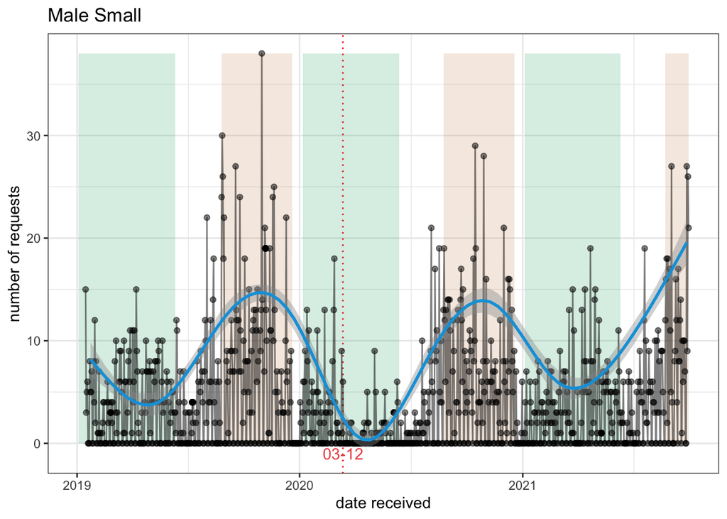

[figure not shown]

[figure not shown]

## Plot of Total Number of Requests and Student Status

To see if student status has an impact on the the number of requests, let us look at the plot of the total number of requests by student status. The count plots for Student and Non-student follow a similar trend as before, so we can conclude that looking at just the total number of requests will be sufficient.

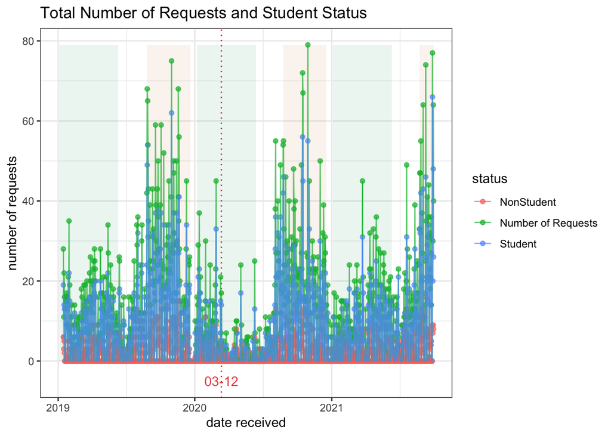